# Project One

Jason Burk

10/26/2019

```r
# Install libraries
library(caret)
library(e1071)
library(class)
library(tidyverse)
```

```r
library(ggplot2)
library(dplyr)
library(data.table)
library(mice)
library(ggalt)
library(usmap)
```

# **Questions:**

# **==============================================**

## **1. How many breweries are present in each state?**

*To find the number of breweries in each state we had to import that data from the given .CSV files and then merge them in R. Once merged we were able to sum up the number of breweries by state.*

```r
# read in the beer data from a .CSV
beers = read.csv("~/03-School/DS 6306/Project-1/Project-One/Beers.csv")

# read in the brewery data from a .CSV
breweries = read.csv("~/03-School/DS 6306/Project-1/Project-One/Breweries.csv")

# combine the beer and brewery data using the brewery ID as the key
combine = merge(beers, breweries, by.x = "Brewery_id", by.y = "Brew_ID")

# change the names of the column headers to match
names(combine)[names(combine) == "Name.x"] <- "Beer_Name"
names(combine)[names(combine) == "Name.y"] <- "Brewery_Name"

# compute the sum of the breweries by state
statesum = count(breweries, vars = State)
```

## **2. Merge beer data with the breweries data. Print the first 6 observations and the last six observations to check the merged file.**

*We merged the beer and brewery data in the previous set of code. Now in order to print the first 6 observations we use the command “head” and it gives us the data for the first 6 observations. Using the command “tail” will give us the last 6 observations*

```r
# find the first 6 and last 6 beers
head(combine)
```

```
##   Brewery_id     Beer_Name Beer_ID   ABV IBU
## 1          1  Get Together    2692 0.045  50
## 2          1 Maggie's Leap    2691 0.049  26
## 3          1    Wall's End    2690 0.048  19
## 4          1       Pumpion    2689 0.060  38
## 5          1    Stronghold    2688 0.060  25
## 6          1   Parapet ESB    2687 0.056  47
##                                 Style Ounces       Brewery_Name        City
## 1                        American IPA     16 NorthGate Brewing  Minneapolis
## 2                  Milk / Sweet Stout     16 NorthGate Brewing  Minneapolis
## 3                   English Brown Ale     16 NorthGate Brewing  Minneapolis
## 4                         Pumpkin Ale     16 NorthGate Brewing  Minneapolis
## 5                     American Porter     16 NorthGate Brewing  Minneapolis
## 6 Extra Special / Strong Bitter (ESB)     16 NorthGate Brewing  Minneapolis
##   State
## 1    MN
## 2    MN
## 3    MN
## 4    MN
## 5    MN
## 6    MN
```

```r
tail(combine)
```

```
##      Brewery_id                 Beer_Name Beer_ID   ABV IBU
## 2405        556             Pilsner Ukiah      98 0.055  NA
## 2406        557  Heinnieweisse Weissebier      52 0.049  NA
## 2407        557           Snapperhead IPA      51 0.068  NA
## 2408        557         Moo Thunder Stout      50 0.049  NA
## 2409        557         Porkslap Pale Ale      49 0.043  NA
## 2410        558 Urban Wilderness Pale Ale      30 0.049  NA
##                        Style Ounces                  Brewery_Name          City
## 2405         German Pilsener     12         Ukiah Brewing Company         Ukiah
## 2406              Hefeweizen     12       Butternuts Beer and Ale Garrattsville
## 2407            American IPA     12       Butternuts Beer and Ale Garrattsville
## 2408      Milk / Sweet Stout     12       Butternuts Beer and Ale Garrattsville
## 2409 American Pale Ale (APA)     12       Butternuts Beer and Ale Garrattsville
## 2410        English Pale Ale     12 Sleeping Lady Brewing Company     Anchorage
##      State
## 2405    CA
## 2406    NY
## 2407    NY
## 2408    NY
## 2409    NY
## 2410    AK
```

## **3. Address the missing values in each column.**

*In order to address the missing values in each column we turned to a function available in the R code libraries. A function called Multivariate Imputaton by Chained Equations (MIcE). We were able to infer values for Alcohol by Volume (ABV) and International Bitterness Units (IBU) where the data was missing.*

```r
# No iteration. But I want to get Predictor-Matrix
init = mice(combine, maxit=0)
predM = init$predictorMatrix

# Do not use following columns to impute values in 'ABV' and 'IBU'. Use the rest.
predM[, c("Beer_Name", "Beer_ID", "Ounces", "Brewery_Name")]=0
imp<-mice(combine, m=5, predictorMatrix = predM)
```

```
##
##  * Please inspect the loggedEvents
```

```r
# Get the final data-frame with imputed values filled in
nona <- complete(imp)

#write.csv(nona, file = "~/03-School/DS 6306/Project-1/Project-One/nona.csv")
#nona = read.csv("~/03-School/DS 6306/Project-1/Project-One/nona.csv")
nona$ABV = nona$ABV * 100
```

## **4. Compute the median alcohol content and international bitterness unit for each state. Plot a bar chart to compare.**

*We were able to compute the median ABV and IBU for each state by incorporating another library available in R. There is a data frame called State Population that contains the abbreviations and state names (and 2015 Census data). We were able to merge the beer data and count the number of breweries by each state - including the District of Columbia.*

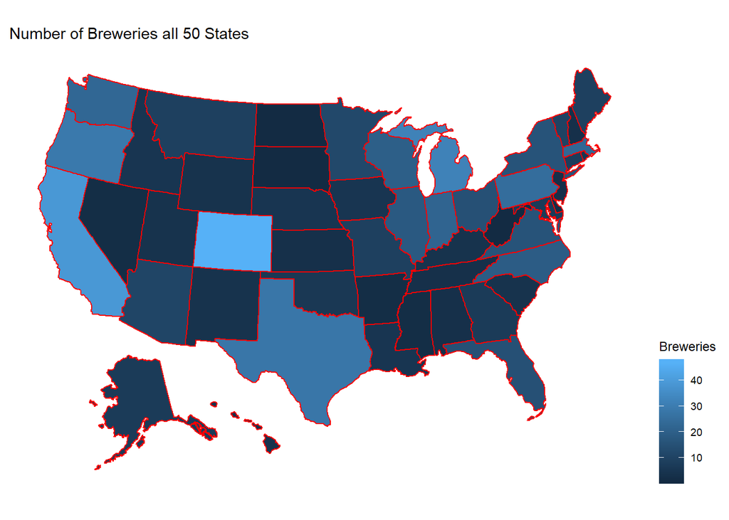

```r
# merge datasets for plotting on maps
temp = statepop
statesum$vars = as.character(statesum$vars)
statesum$vars = str_trim(statesum$vars)
statebrew = merge(statesum, temp, by.x = "vars", by.y = "abbr")
names(statebrew)[names(statebrew) == "vars"] <- "abbr"
names(statebrew)[names(statebrew) == "n"] <- "count"
statebrew$per_cap <- statebrew$pop_2015 / statebrew$count

#  plot of the Number of Beers by State
plot_usmap(data = statebrew, values = "count", color = "red") +
  scale_fill_continuous(name = "Breweries", label = scales::comma) + labs(title = "Number of Breweries all 50 States") + theme(legend.position = "right")
```

```r
# remove n/a's from the data
nona$State = as.character(nona$State)
nona$State = str_trim(nona$State)

# merge data to one master data frame
allbrews = merge(statebrew, nona, by.x = "abbr", by.y = "State")

# compute the ABV state stats
stateABV = allbrews %>%
  group_by(abbr) %>%
  summarise_each(funs(max, min, mean, median, sd), ABV)
```

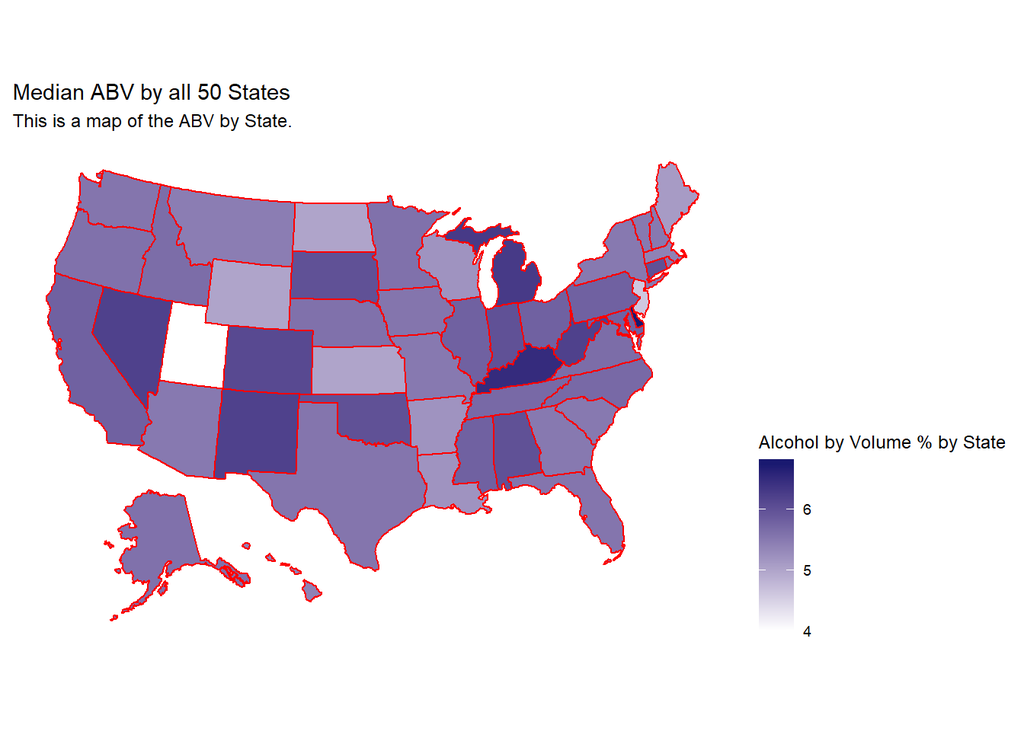

```r
# compute the IBU state stats
stateIBU = allbrews %>%
  group_by(abbr) %>%
  summarise_each(funs(max, min, mean, median, sd), IBU)

# Merge data files
stateABV = merge(temp, stateABV, by.x = "abbr", by.y = "abbr")
stateIBU = merge(temp, stateIBU, by.x = "abbr", by.y = "abbr")

### ABV usa -->
plot_usmap(data = stateABV, values = "median", color = "red") + labs(title = "Median ABV by all 50 States", subtitle = "This is a map of the ABV by State.") +
scale_fill_continuous(
low = "white", high = "midnightblue", name = "Alcohol by Volume % by State"  ) + theme(legend.position = "right")
```

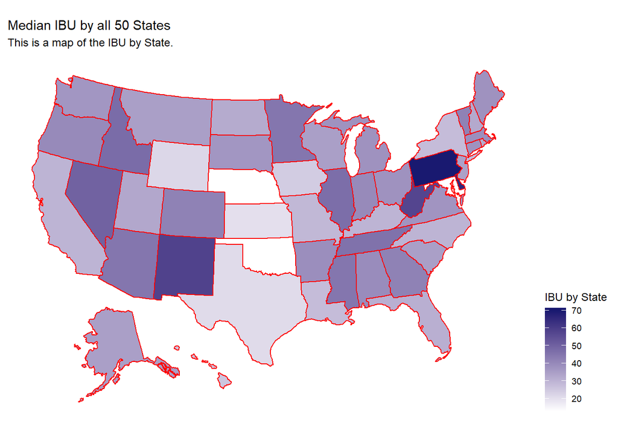

```r
### IBU usa -->
plot_usmap(data = stateIBU, values = "median", color = "red") + labs(title = "Median IBU by all 50 States", subtitle = "This is a map of the IBU by State.") +
scale_fill_continuous(
low = "white", high = "midnightblue", name = "IBU by State"  ) + theme(legend.position = "right")
```

[figure not shown]

```r
# Make top 10 Median ABV by State
nona$State = as.character(nona$State)
nona$State = str_trim(nona$State)
medianABVIBU<-nona%>%group_by(State)%>%summarize(medianABV=median(ABV),medianIBU=median(IBU))
top10medABV=head(medianABVIBU,10)
top10medIBU=head(medianABVIBU,10)
top10medABV%>%ggplot(aes(x=reorder(State,-medianABV),y=medianABV))+
 geom_bar(stat="identity",fill="midnightblue")+geom_text(aes(label=medianABV), vjust=1.6, color="white", size=3)+
ggtitle("Top 10 Highest Median Alcohol by Volumes by State")+xlab("States")+ylab("Alcohol by Volume")
```

[figure not shown]

```r
# Make top 10 Median IBU by State
top10medIBU%>%ggplot(aes(x=reorder(State,-medianIBU),y=medianIBU))+
 geom_bar(stat="identity",fill="midnightblue")+geom_text(aes(label=medianIBU), vjust=1.6, color="white", size=3)+
ggtitle("Top 10 Highest Median International Bitterness Units by State")+xlab("States")+ylab("Alcohol by Volume")
```

```r
top10medIBU[order(-top10medIBU$medianIBU),]
```

```
## # A tibble: 10 x 3
##    State medianABV medianIBU
##    <chr>     <dbl>     <dbl>
##  1 DE         6.75      66
##  2 AZ         5.5       45
##  3 CO         6.1       42
##  4 AL         6         39.5
##  5 AR         5.2       39
##  6 CT         6         38
##  7 DC         6.25      35.5
##  8 AK         5.6       35
##  9 FL         5.55      31
## 10 CA         5.8       30
```

## **5. Which state has the maximum alcoholic (ABV) beer? Which state has the most bitter (IBU) beer?**

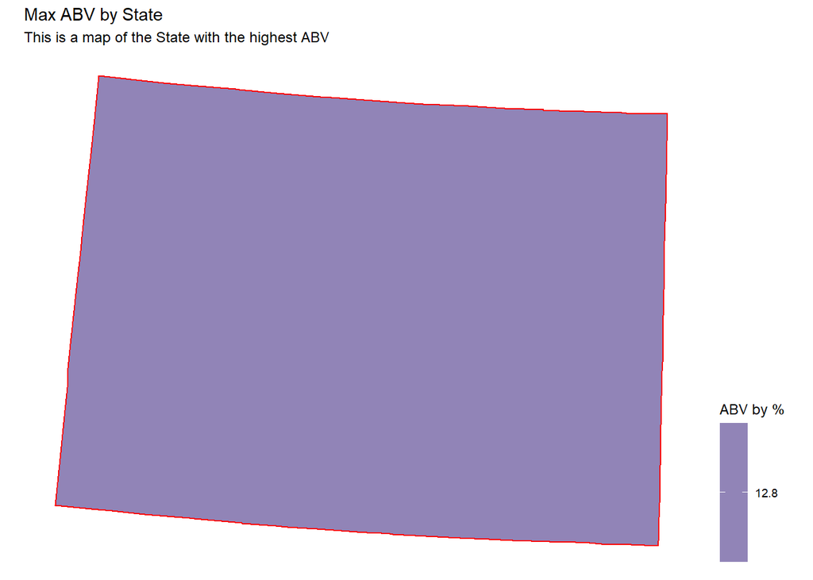

```r
#### Max ABV
plot_usmap(data = stateABV, values = "max", include = "CO", color = "red") + labs(title = "Max ABV by State", subtitle = "This is a map of the State with the highest ABV") +
  scale_fill_continuous(
    low = "white", high = "midnightblue", name = "ABV by %"  ) + theme(legend.position = "right")
```

[figure not shown]

```r
#### Max IBU
plot_usmap(data = stateIBU, values = "max", include = "CO", color = "red") + labs(title = "Max IBU by State", subtitle = "This is a map of the State with the highest IBU") +
  scale_fill_continuous(
    low = "white", high = "midnightblue", name = "IBU"  ) + theme(legend.position = "right")
```

## **6. Comment on the summary statistics and distribution of the ABV variable.**

```r
# print out the summary statistics for ABV mean and ABV by all data
summary(stateABV$mean)
```

```
##    Min. 1st Qu.  Median    Mean 3rd Qu.    Max.
##   5.188   5.671   5.917   5.920   6.110   6.982
```

```r
summary(allbrews$ABV)
```

```
##    Min. 1st Qu.  Median    Mean 3rd Qu.    Max.
##   0.100   5.000   5.700   6.011   6.800  12.800
```

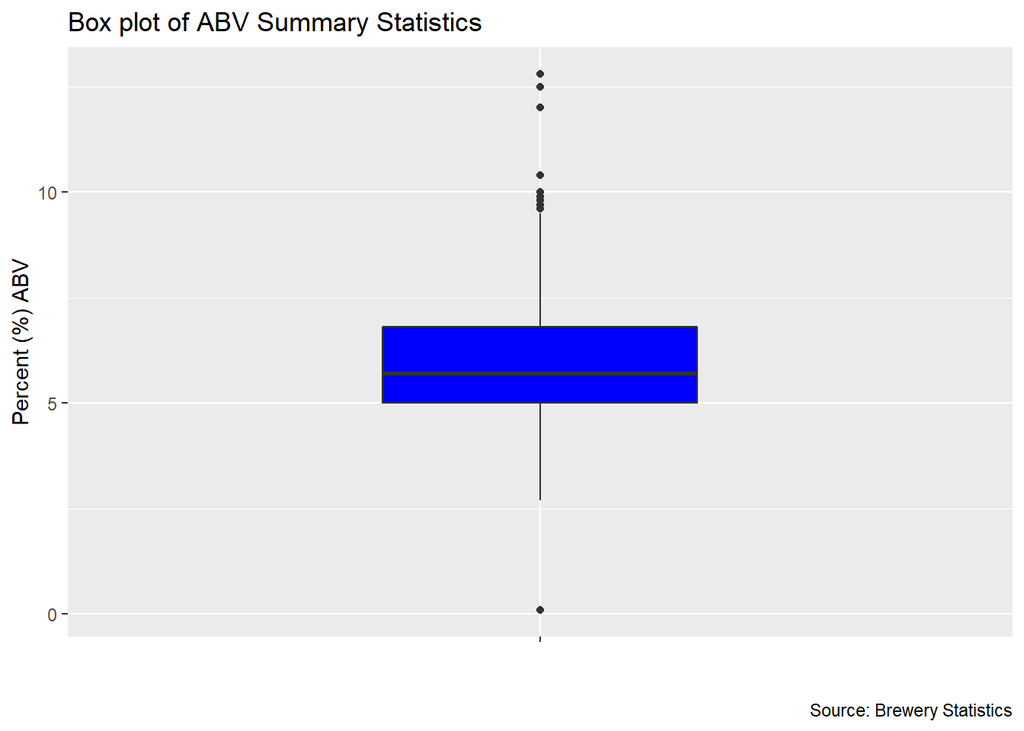

```r
# Make a boxplot of the ABV summary statistics
nona%>%ggplot(aes(x="", y=ABV,fill=ABV))+geom_boxplot(width=.4,fill="blue")+ylab("ABV")+labs(title="Box plot of ABV Summary Statistics", caption = "Source: Brewery Statistics", x="", y="Percent (%) ABV")
```

## **7. Is there an apparent relationship between the bitterness of the beer and its alcoholic content? Draw a scatter plot. Make your best judgment of a relationship and EXPLAIN your answer.**

[figure not shown]

```r
#### Max ABV by state
plot_usmap(data = stateABV, values = "max", color = "red") + labs(title = "Median ABV by all 50 States", subtitle = "This is a map of the ABV by State.") +
  scale_fill_continuous(
    low = "white", high = "midnightblue", name = "Alcohol by Volume by State"  ) + theme(legend.position = "right")
```

[figure not shown]

```r
#### Max IBU by state
plot_usmap(data = stateIBU, values = "max", color = "red") + labs(title = "Median IBU by all 50 States", subtitle = "This is a map of the IBU by State.") +
  scale_fill_continuous(
    low = "white", high = "midnightblue", name = "IBU by State"  ) + theme(legend.position = "right")
```

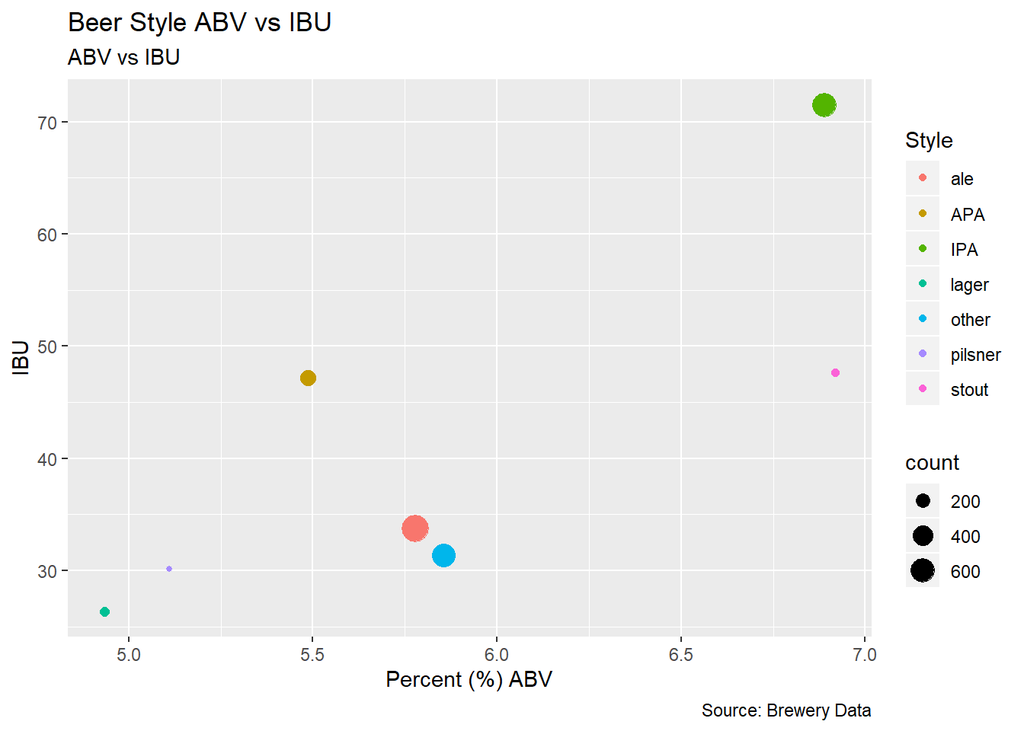

```r
# find common beer styles for EDA
styles = c("IPA", "APA", "Blonde ale", "brown ale", "red ale", "ale", "lager", "stout", "cider", "porter", "pilsner", "hefeweizen" ,"pilsener", "witbier", "fruit", "KÃ¶lsch")
styles = c("IPA", "APA", "ale", "lager", "stout", "pilsner", "pilsener")
beers = data.frame(styles)
beers$nodata = 0
allbrews$class = ""
allbrews$used = FALSE
allbrews$Beer_Name = as.character(allbrews$Beer_Name)
beers$styles = as.character(beers$styles)
for (i in 1:dim(allbrews)[1]) {
  for (j in 1:dim(beers)[1]) {
    x = beers[j,]$style
    y = allbrews[i,]$Style
    if (str_detect(y, regex(x, ignore_case = TRUE)) & allbrews[i,]$used != TRUE) {
      allbrews[i,]$class = beers[j,]$style
      allbrews[i,]$used = TRUE
    }
  }
}
for (i in 1:dim(allbrews)[1]) {
  if (allbrews[i,]$used == FALSE) {
    allbrews[i,]$class = "other"
  }
  if (allbrews[i,]$class == "Pilsener" | allbrews[i,]$class == "pilsener") {
    allbrews[i,]$class = "pilsner"
  }
}

# find the number of beers in each style
stylesum = count(allbrews, vars = class)

# compute the means for the ABV and IBU by style and then plot
stylemeans = stylesum
stylemeans$ABVmean = 0
stylemeans$IBUmean = 0
stylemeans$ABVtotal = 0
stylemeans$IBUtotal = 0
for (i in 1:dim(allbrews)[1]) {
  for (j in 1:dim(stylesum)[1]) {

    if (allbrews[i,]$class == stylesum[j,]$vars) {
      stylemeans[j,]$ABVtotal = stylemeans[j,]$ABVtotal + allbrews[i,]$ABV
      stylemeans[j,]$IBUtotal = stylemeans[j,]$IBUtotal + allbrews[i,]$IBU
    }

  }
}
for (j in 1:dim(stylemeans)[1]) {
  stylemeans[j,]$ABVmean = stylemeans[j,]$ABVtotal / stylemeans[j,]$n
  stylemeans[j,]$IBUmean = stylemeans[j,]$IBUtotal / stylemeans[j,]$n
}
stylemeans$ABVmean = round(stylemeans$ABVmean, 4)
stylemeans$IBUmean = round(stylemeans$IBUmean, 4)
names(stylemeans)[names(stylemeans) == "vars"] <- "abbr"
names(stylemeans)[names(stylemeans) == "n"] <- "count"
names(stylemeans)[names(stylemeans) == "abbr"] <- "Style"

# plot ABV vs IBU to see any relationships
gg <- ggplot(stylemeans, aes(x=ABVmean, y=IBUmean)) +
  geom_point(aes(col=Style, size=count)) +
  labs(subtitle="ABV vs IBU",
       y="IBU",
       x="Percent (%) ABV",
       title="Beer Style ABV vs IBU",
       caption = "Source: Brewery Data")

plot(gg)
```

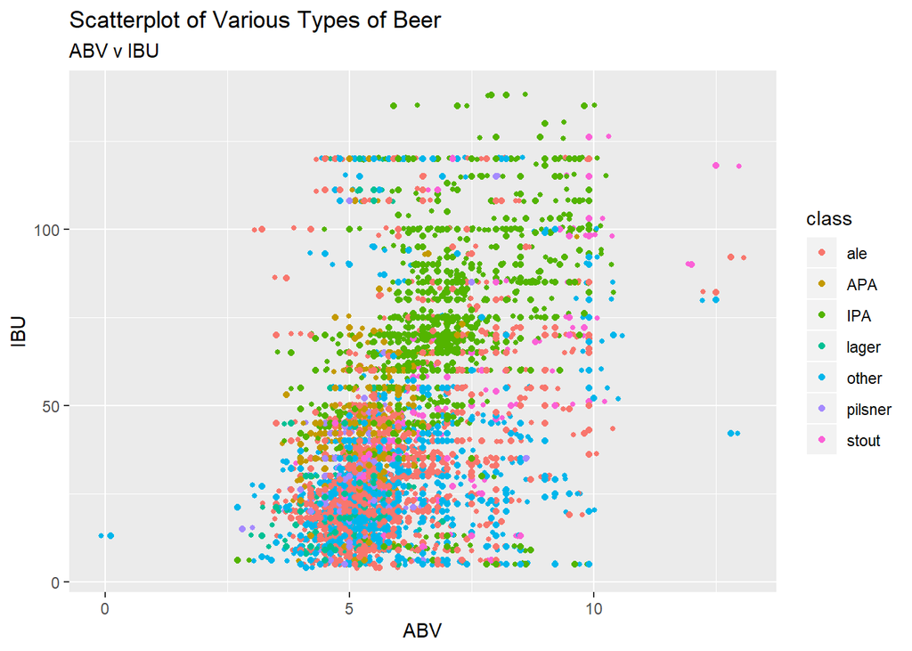

```r
# Make a scatterplot of all types of beer
g <- ggplot(allbrews, aes(ABV, IBU, color=class))
g + geom_jitter(width = .5, size=1 ) +
  geom_point(aes(col=class)) +
  labs(subtitle="ABV v IBU",
       y="IBU",
       x="ABV",
       title="Scatterplot of Various Types of Beer")
```

## **8. Budweiser would also like to investigate the difference with respect to IBU and ABV between IPAs (India Pale Ales) and other types of Ale (any beer with “Ale” in its name other than IPA). You decide to use KNN classification to investigate this relationship. Provide statistical evidence one way or the other. You can of course assume your audience is comfortable with percentages … KNN is very easy to understand.**

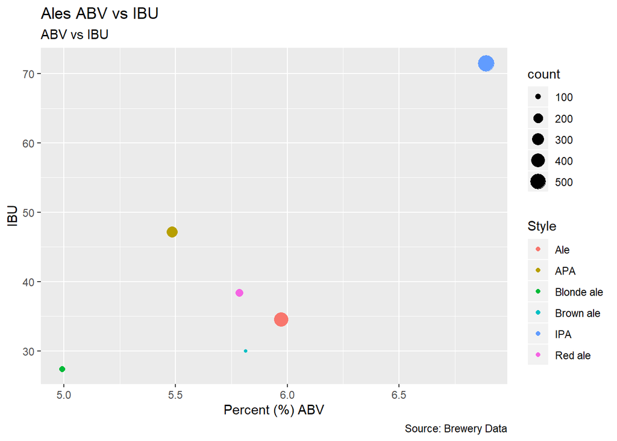

```r
# find common ale styles for EDA
allAles = allbrews
stylesofAle = c("IPA", "APA", "Blonde ale", "Brown ale", "Red ale", "Ale")
ales = data.frame(stylesofAle)
ales$nodata = 0
allAles$class = ""
allAles$used = FALSE
allAles$Beer_Name = as.character(allAles$Beer_Name)
ales$stylesofAle = as.character(ales$stylesofAle)
styleSubset <- allAles
allAles <-styleSubset[grep(paste(stylesofAle,collapse="|"),styleSubset$Style,ignore.case = TRUE),]
for (i in 1:dim(allAles)[1]) {
  for (j in 1:dim(ales)[1]) {
    x = ales[j,]$stylesofAle
    y = allAles[i,]$Style
    if (str_detect(y, regex(x, ignore_case = TRUE)) & allAles[i,]$used != TRUE) {
      allAles[i,]$class = ales[j,]$stylesofAle
      allAles[i,]$used = TRUE
    }
  }
}

# find the number of ales
stylesum = count(allAles, vars = class)

# compute the means for the ABV and IBU by style and then plot
stylemeans = stylesum
stylemeans$ABVmean = 0
stylemeans$IBUmean = 0
stylemeans$ABVtotal = 0
stylemeans$IBUtotal = 0
for (i in 1:dim(allAles)[1]) {
  for (j in 1:dim(stylesum)[1]) {

    if (allAles[i,]$class == stylesum[j,]$vars) {
      stylemeans[j,]$ABVtotal = stylemeans[j,]$ABVtotal + allAles[i,]$ABV
      stylemeans[j,]$IBUtotal = stylemeans[j,]$IBUtotal + allAles[i,]$IBU
    }

  }
}

for (j in 1:dim(stylemeans)[1]) {
  stylemeans[j,]$ABVmean = stylemeans[j,]$ABVtotal / stylemeans[j,]$n
  stylemeans[j,]$IBUmean = stylemeans[j,]$IBUtotal / stylemeans[j,]$n
}
stylemeans$ABVmean = round(stylemeans$ABVmean, 4)
stylemeans$IBUmean = round(stylemeans$IBUmean, 4)
names(stylemeans)[names(stylemeans) == "vars"] <- "abbr"
names(stylemeans)[names(stylemeans) == "n"] <- "count"
names(stylemeans)[names(stylemeans) == "abbr"] <- "Style"

# plot ABV vs IBU to see any relationships
gg <- ggplot(stylemeans, aes(x=ABVmean, y=IBUmean)) +
  geom_point(aes(col=Style, size=count)) +
  labs(subtitle="ABV vs IBU",
       y="IBU",
       x="Percent (%) ABV",
       title="Ales ABV vs IBU",
       caption = "Source: Brewery Data")

plot(gg)
```

```r
#### Find optimal k-factor
styleSubset <- allAles%>%select(Style,ABV,IBU)
allAles <-styleSubset[grep(paste(stylesofAle,collapse="|"),styleSubset$Style,ignore.case = TRUE),]
allAles$styleClass <- ifelse(grepl("IPA", allAles$Style,ignore.case = T), "IPA",
         ifelse(grepl("Ale", allAles$Style, ignore.case = T), "Ale", "Other"))
head(allAles)
```

```
##                      Style ABV IBU styleClass
## 1             American IPA 5.7  70        IPA
## 2 American Amber / Red Ale 5.1  18        Ale
## 4             American IPA 6.0  70        IPA
## 6      American Blonde Ale 4.9   9        Ale
## 7      American Blonde Ale 5.0  15        Ale
## 8             American IPA 6.8  88        IPA
```

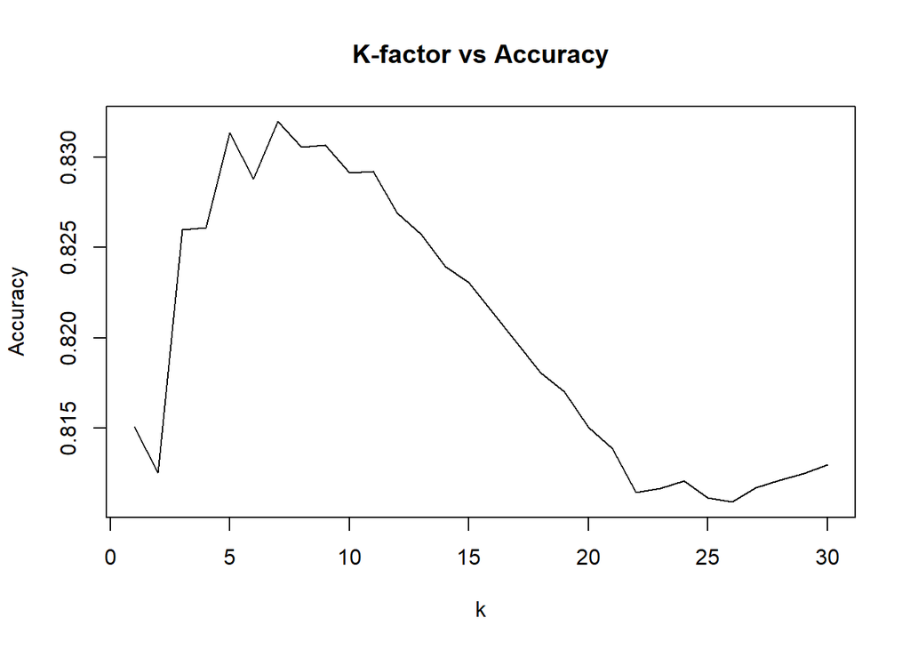

```r
iterations = 100
numks = 30
perc=.8
masterAcc = matrix(nrow = iterations, ncol = numks)
for(j in 1:iterations)
{
  accs = data.frame(accuracy = numeric(30), k = numeric(30))
  trainIndices = sample(1:dim(allAles)[1],round(perc * dim(allAles)[1]))
  train = allAles[trainIndices,]
  test = allAles[-trainIndices,]
  for(i in 1:numks)
  {
    classifications = knn(train[,c(2,3)],test[,c(2,3)],train$styleClass, prob = TRUE, k = i)
    table(test$styleClass,classifications)
    CM = confusionMatrix(table(test$styleClass,classifications))
    masterAcc[j,i] = CM$overall[1]
  }
}
MeanAcc = colMeans(masterAcc)
plot(seq(1,numks,1),MeanAcc, type = "l", xlab = "k", ylab = "Accuracy", main = "K-factor vs Accuracy")
```

```r
# k=7 based on previous data and charts
k = 7

# Make a confusion matrix for the k=7
classifications = knn(train[,c(2,3)],test[,c(2,3)],train$styleClass, prob = TRUE, k = k)
table(test$styleClass,classifications)
```

```
##      classifications
##       Ale IPA
##   Ale 168  28
##   IPA  37  83
```

```r
confusionMatrix(table(test$styleClass,classifications))
```

```
## Confusion Matrix and Statistics
##
##      classifications
##       Ale IPA
##   Ale 168  28
##   IPA  37  83
##
##                Accuracy : 0.7943
##                  95% CI : (0.7455, 0.8375)
##     No Information Rate : 0.6487
##     P-Value [Acc > NIR] : 1.141e-08
##
##                   Kappa : 0.5569
##
##  Mcnemar's Test P-Value : 0.3211
##
##             Sensitivity : 0.8195
##             Specificity : 0.7477
##          Pos Pred Value : 0.8571
##          Neg Pred Value : 0.6917
##              Prevalence : 0.6487
##          Detection Rate : 0.5316
##    Detection Prevalence : 0.6203
##       Balanced Accuracy : 0.7836
##
##        'Positive' Class : Ale
##
```

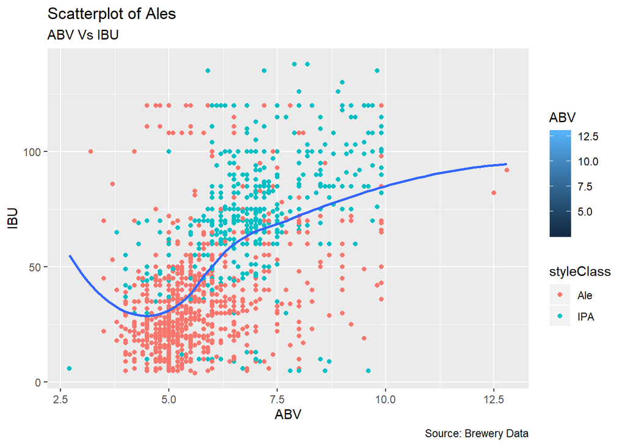

```r
# Make a scatterplot of Ales v IPA
gg <- ggplot(allAles, aes(x=ABV, y=IBU)) +
  geom_point(aes(fill=ABV,col=styleClass)) +
  geom_smooth(method="loess", se=F) +
  labs(subtitle="ABV Vs IBU",
       y="IBU",
       x="ABV",
       title="Scatterplot of Ales",
       caption = "Source: Brewery Data")

plot(gg)
```

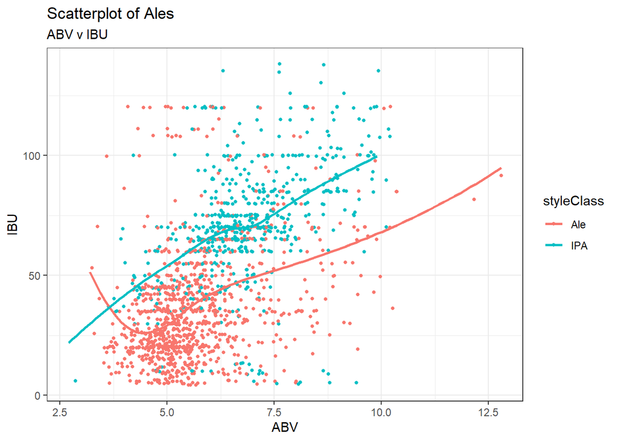

```r
# Make a scatterplot with jitter of ales vs IPA
theme_set(theme_bw())  # pre-set the bw theme.

# Plot a scatterplot of the ABV v IBU by ale or IPA
g <- ggplot(allAles, aes(ABV, IBU, color=styleClass))
g + geom_jitter(width = .5, size=1 ) +
  geom_smooth(method="loess", se=F) +
  labs(subtitle="ABV v IBU",
       y="IBU",
       x="ABV",
       title="Scatterplot of Ales")
```

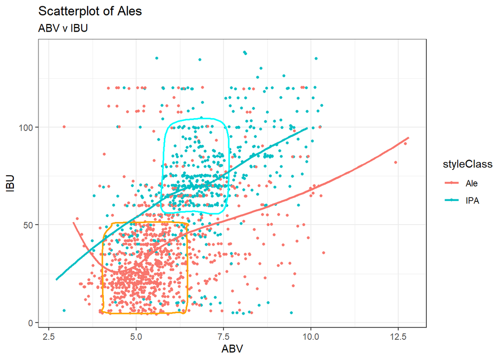

```r
# define the circled region parameters
ale_select <- allAles[allAles$IBU > 5 & allAles$IBU <= 50 & allAles$ABV > 4 & allAles$ABV < 6.5,]
ipa_select <- allAles[allAles$IBU > 55 & allAles$IBU <= 100 & allAles$ABV > 5.8 & allAles$ABV < 7.6,]

# Plot a scatterplot of ABV v IBU by ale or IBA and circle regions with each
g <- ggplot(allAles, aes(ABV, IBU, color=styleClass))
g + geom_jitter(width = .5, size=1 ) +
  geom_encircle(aes(x=ABV,y=IBU), data=ale_select,color="orange", size=2, expand=0.008) +
  geom_encircle(aes(x=ABV,y=IBU), data=ipa_select,color="cyan", size=2, expand=0.008) +
  geom_smooth(method="loess", se=F) +
  labs(subtitle="ABV v IBU",
       y="IBU",
       x="ABV",
       title="Scatterplot of Ales")
```

## **9. Knock their socks off! Find one other useful inference from the data that you feel Budweiser may be able to find value in. You must convince them why it is important and back up your conviction with appropriate statistical evidence.**

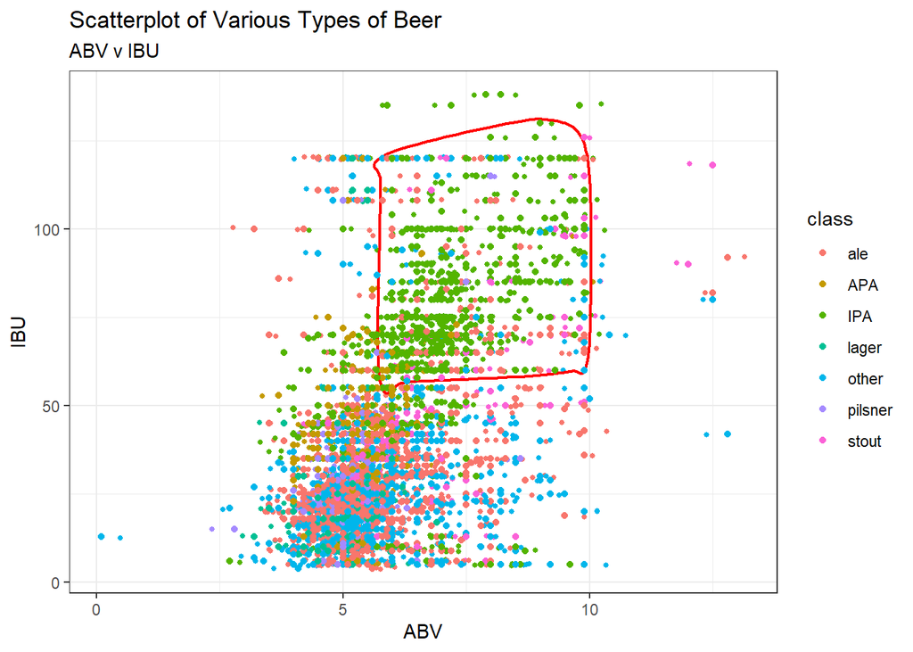

```r
# Plot the IPA's on a scatterplot and circle them
ipa_select <- allAles[allAles$IBU > 55 & allAles$IBU <= 130 & allAles$ABV > 5.8 & allAles$ABV < 11,]
g <- ggplot(allbrews, aes(ABV, IBU, color=class))
g + geom_jitter(width = .5, size=1 ) +
  geom_encircle(aes(x=ABV,y=IBU), data=ipa_select,color="red", size=2, expand=0.008) +
  geom_point(aes(col=class)) +
  labs(subtitle="ABV v IBU",
       y="IBU",
       x="ABV",
       title="Scatterplot of Various Types of Beer")
```

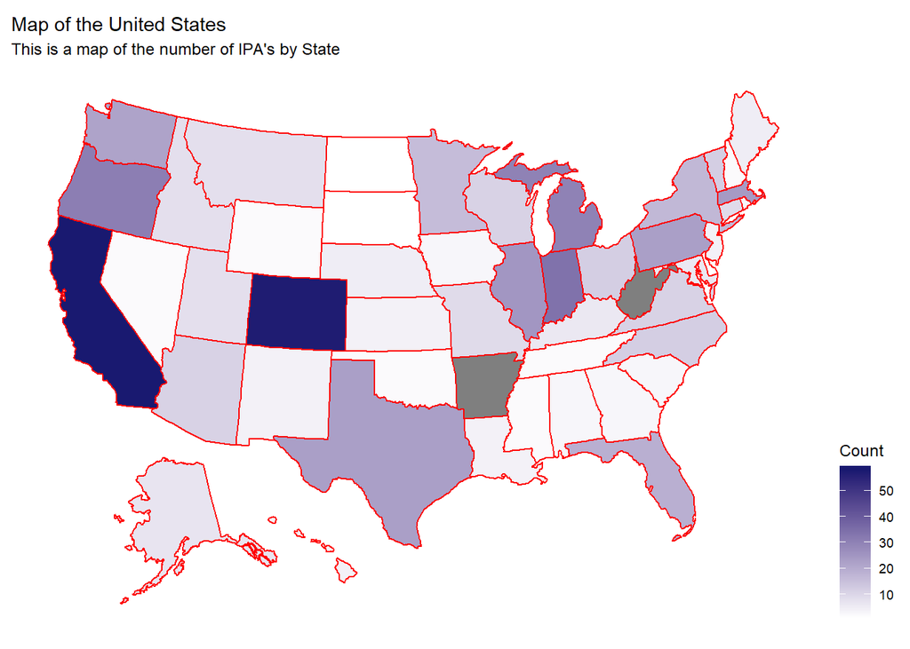

```r
# Compute the ales and IPA's in a new data frame
styleSubset <- allAles%>%select(Style,ABV,IBU)
allAles <-styleSubset[grep(paste(stylesofAle,collapse="|"),styleSubset$Style,ignore.case = TRUE),]
allAles$styleClass <- ifelse(grepl("IPA", allAles$Style,ignore.case = T), "IPA",
         ifelse(grepl("Ale", allAles$Style, ignore.case = T), "Ale", "Other"))
stylesofAle = c("IPA")
styleSubset <- allbrews%>%select(abbr,count,fips,ABV,IBU,Style,class)
allIPA <-styleSubset[grep(paste(stylesofAle,collapse="|"),styleSubset$Style,ignore.case = TRUE),]
allIPA$styleClass <- ifelse(grepl("IPA", allIPA$class,ignore.case = T), "IPA",)

# Find the number of IPA's in each state
IPAsum = count(allIPA, vars = abbr)
for (i in 1:dim(allIPA)[1]) {
  for (j in 1:dim(IPAsum)[1]) {
    x = IPAsum[j,]$vars
    y = allIPA[i,]$abbr
    if (x == y) {
      allIPA[i,]$count = IPAsum[j,]$n
    }
  }
}

### IPA US Map
plot_usmap(data = allIPA, values = "count", color = "red") + labs(title = "Map of the United States", subtitle = "This is a map of the number of IPA's by State") +
  scale_fill_continuous(low = "white", high = "midnightblue",name = "Count", label = scales::comma) +
  theme(legend.position = "right")
```

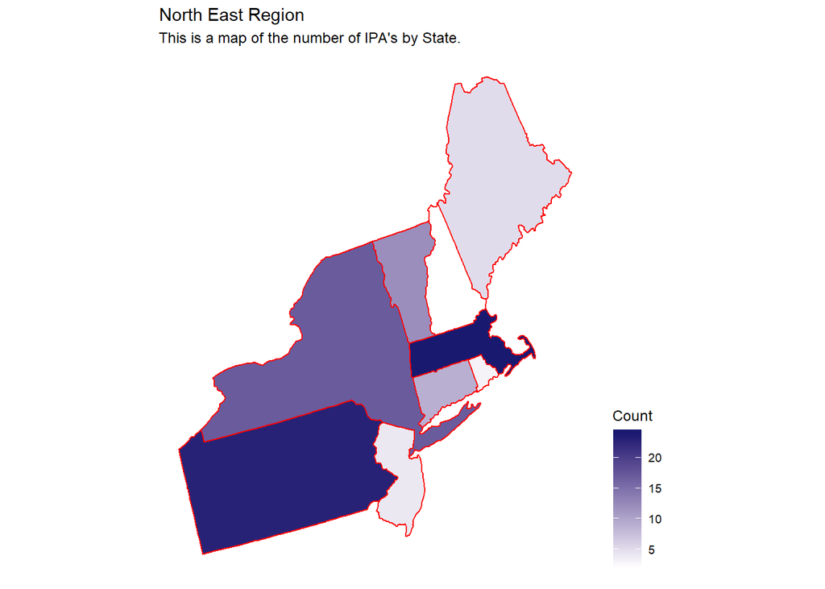

```r
### IPA's North east
plot_usmap(include = .northeast_region, data = allIPA, values = "count", color = "red") + labs(title = "North East Region", subtitle = "This is a map of the number of IPA's by State.") +
  scale_fill_continuous(
    low = "white", high = "midnightblue", name = "Count"  ) + theme(legend.position = "right")
```

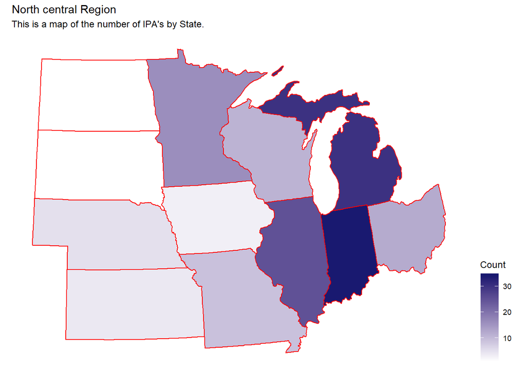

```r
### IPA's North Central
plot_usmap(include = .north_central_region, data = allIPA, values = "count", color = "red") + labs(title = "North central Region", subtitle = "This is a map of the number of IPA's by State.") +
  scale_fill_continuous(
    low = "white", high = "midnightblue", name = "Count") + theme(legend.position = "right")
```

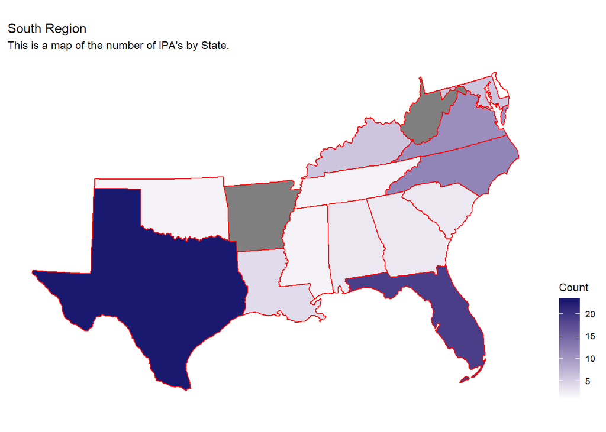

```r
### IPA's South Central
plot_usmap(include = .south_region, data = allIPA, values = "count", color = "red") + labs(title = "South Region", subtitle = "This is a map of the number of IPA's by State.") +
  scale_fill_continuous(
    low = "white", high = "midnightblue", name = "Count") + theme(legend.position = "right")
```

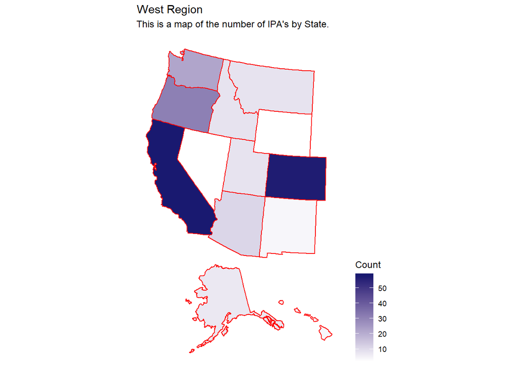

```r
### IPA's West Central
plot_usmap(include = .west_region, data = allIPA, values = "count", color = "red") + labs(title = "West Region", subtitle = "This is a map of the number of IPA's by State.") +
  scale_fill_continuous(
    low = "white", high = "midnightblue", name = "Count") + theme(legend.position = "right")
```